# Housing Data Analysis

Michal Sieczkos

8/08/2022

# 0. Loading Required Libraries

```r
library(ggplot2)
library(validate)
library(tidyverse)
library(dplyr)
library(dlookr)
library(tree)
```

# 1. Organise and clean the data

## 1.1 Subset the data into the specific dataset allocated

```r
# Assign your student id into the variable SID, for example:
SID <- 2136823                  # This is an example, replace 2101234 with your actual ID
SIDoffset <- (SID %% 25) + 1    # Your SID mod 25 + 1

load("houses-analysis.Rda")
# Now subset the data set
# Pick every 25th observation starting from your offset
# Put into your data frame named mydf (you can rename it)
houses <- houses.analysis2[seq(from=SIDoffset,to=nrow(houses.analysis2),by=25),]
# remove houses.analysis2 as only an intermediate step
rm(houses.analysis2)
```

## 1.2 Data quality analysis

Data quality is a pivotal step when considering data analysis that refers to the ability of a set of data to serve an intended purpose. It is crucial since even ingenious and thorough analysis of corrupt, biased or wrong data will not protect the data scientist from undertaking a misleading analysis, than can ultimately lead to incorrect results that lack sense, which can be really problematic. Raw data files may have a lot of errors, including wrong data types, wrong category labels, unexpected or unknown values etc.

In order to assess the quality of the data, I would start with ensuring that the data frame is correct, meaning that I would check whether the data attributes are of correct type, and compliant with the data description.

The next step would be to check the general data properties, such as checking the dimensions, labels, ranges of values, as well as frequency tables. Such procedures will help me gain initial insight into the data to look for some possible errors, such as outliers and incorrect values.

Finally, the last step would be to check for the missing values in the data, and decide on the way in which they should be handled.

```r
# Examining the first 6 rows to get an initial insight into the data frame
head(houses)
```

|  | Rooms | Type | Price | Bedrooms | Bathroom | Car | Landsize | BuildingArea | YearBuilt | Distance | Propertycount | ID | urban.ind |
| --- | --- | --- | --- | --- | --- | --- | --- | --- | --- | --- | --- | --- | --- |
| 38 | 2 | h | 1030000 | 2 | 1 | 1 | 172 | 81 | 1930 | 2.5 | 4019 | 6634 | 1 |
| 75 | 4 | h | 978000 | 4 | 3 | 2 | 532 | NA | NA | 13.5 | 3464 | 8598 | 0 |
| 145 | 3 | h | 1120000 | 3 | 1 | 2 | 506 | 120 | 1930 | 13.8 | 5301 | 9871 | 0 |
| 188 | 3 | h | 781000 | 3 | 1 | 2 | 533 | 117 | 1970 | 11.1 | 5132 | 6445 | 0 |
| 229 | 2 | u | 678000 | 2 | 1 | 2 | 0 | NA | NA | 6.3 | 4836 | 2246 | 1 |
| 298 | 2 | h | 940000 | 2 | 1 | 1 | 330 | NA | NA | 5.9 | 6567 | 2628 | 1 |

```r
# Following chunk of code checks whether the names and amount of variables are correct
names(houses)
```

```
 [1] "Rooms"         "Type"          "Price"
 [4] "Bedrooms"      "Bathroom"      "Car"
 [7] "Landsize"      "BuildingArea"  "YearBuilt"
[10] "Distance"      "Propertycount" "ID"
[13] "urban.ind"
```

```r
# Checking the dimensions of the data set, as well as the data types
str(houses)
```

```
'data.frame':   295 obs. of  13 variables:
 $ Rooms        : int  2 4 3 3 2 2 3 3 3 4 ...
 $ Type         : chr  "h" "h" "h" "h" ...
 $ Price        : num  1030000 978000 1120000 781000 678000 940000 1050000 968000 851000 790000 ...
 $ Bedrooms     : num  2 4 3 3 2 2 3 3 3 4 ...
 $ Bathroom     : num  1 3 1 1 1 1 2 1 3 2 ...
 $ Car          : num  1 2 2 2 2 1 2 1 1 2 ...
 $ Landsize     : num  172 532 506 533 0 330 318 227 557 570 ...
 $ BuildingArea : num  81 NA 120 117 NA NA 160 NA 181 NA ...
 $ YearBuilt    : num  1930 NA 1930 1970 NA ...
 $ Distance     : num  2.5 13.5 13.8 11.1 6.3 5.9 5.9 11 10.5 10.5 ...
 $ Propertycount: num  4019 3464 5301 5132 4836 ...
 $ ID           : num  6634 8598 9871 6445 2246 ...
 $ urban.ind    : num  1 0 0 0 1 1 1 0 0 0 ...
```

It can be seen that the variable *Rooms* is an integer variable, which is correct in this case. Thus no further action is necessary.

- *Type* is a character variable, which is not wrong, although for the purpose of the analysis it would be beneficial to convert it to the factor type. Such operation will be performed in further stage of the analysis.
- *Price* is a numeric variable, which is correct, meaning that no further actions will be taken.
- *Bedrooms* is of numeric type, although for the purpose of the analysis it should be converted to integer since it can only have discrete values.
- *Bathroom* variable is a numeric variable, similarly as above, it should be converted to the integer type.
- *Car* variable is of numeric type, and as well as the previous two variables, will be converted to the integer type.
- *Landsize* is a numeric variable, which is correct and will not be changed.
- *BuildingArea* is numerical, and it does not require any changes.
- *YearBuilt* is of numeric type, though it should be changed to integer type.
- *Distance* is a numeric variable, which is correct in this case.
- *PropertyCount* is numerical, although since the number of properties can only have discrete values, it will be changed to integer type,
- *ID* is a numeric variable, which does not seem to be correct since it should be categorical. That is why it will be converted to character type.
- *urban.ind* is of numeric type, although it is a mistake since it is a binary variable that indicates whether the property is within 10 miles of the commercial business district, and for that reason it will be changed to factor.

Moreover, in order to follow the principles of literate programming, the variable *Propertycount* should be renamed to *PropertyCount*.

```r
# For the purpose of gaining an overview of each variable and check the attributes ranges, I have used the summary() function
summary(houses)
```

```
     Rooms           Type               Price
 Min.   :1.000   Length:295         Min.   : 248500
 1st Qu.:2.000   Class :character   1st Qu.: 617675
 Median :3.000   Mode  :character   Median : 825000
 Mean   :2.756                      Mean   : 852232
 3rd Qu.:3.000                      3rd Qu.:1073000
 Max.   :6.000                      Max.   :1490000

    Bedrooms        Bathroom           Car
 Min.   :0.000   Min.   :-1.000   Min.   :0.000
 1st Qu.:2.000   1st Qu.: 1.000   1st Qu.:1.000
 Median :3.000   Median : 1.000   Median :1.000
 Mean   :2.719   Mean   : 1.349   Mean   :1.593
 3rd Qu.:3.000   3rd Qu.: 2.000   3rd Qu.:2.000
 Max.   :6.000   Max.   : 3.000   Max.   :6.000

    Landsize       BuildingArea     YearBuilt
 Min.   :   0.0   Min.   :  0.0   Min.   : 123
 1st Qu.: 168.5   1st Qu.: 90.0   1st Qu.:1950
 Median : 372.0   Median :114.0   Median :1970
 Mean   : 479.3   Mean   :123.3   Mean   :1957
 3rd Qu.: 606.5   3rd Qu.:150.0   3rd Qu.:1990
 Max.   :6996.0   Max.   :475.0   Max.   :2220
                  NA's   :126     NA's   :104
    Distance     Propertycount         ID
 Min.   : 1.60   Min.   :  790   Min.   :  29
 1st Qu.: 6.60   1st Qu.: 4114   1st Qu.:2290
 Median :10.20   Median : 6543   Median :4787
 Mean   :10.69   Mean   : 7634   Mean   :4866
 3rd Qu.:13.80   3rd Qu.:10331   3rd Qu.:7270
 Max.   :38.00   Max.   :21650   Max.   :9951

   urban.ind
 Min.   :0.0000
 1st Qu.:0.0000
 Median :0.0000
 Mean   :0.4915
 3rd Qu.:1.0000
 Max.   :1.0000
```

From the summary() output it has been noticed that variables *BuildingArea* and *YearBuilt* have a lot of NA values, what could mean that our data set is incomplete, what in result could be problematic when building a model in further stages.

According to data description, property ID should be unique for each property, therefore it has been checked using table() function.

```r
# Checking whether each value in ID is unique using table() and unique() functions
table(unique(houses$ID) > 1)
```

```
TRUE
 295
```

Since the data set has 295 observations, it has been confirmed that each property has an unique ID.

In order to search for unusual values in the columns, frequency table for the values has been implemented. Moreover, it is possible to see the ranges of the variables more closely, which could be helpful in identifying eventual outliers.

```r
# Following chunk of code prints the frequency table for each variable in the data set
sapply(houses, table)
```

```
$Rooms

  1   2   3   4   5   6
 17  96 133  42   5   2

$Type

  h  h    t   u
200   1  23  71

$Price

 248500  280000   3e+05  327000  335000  336000  357000
      1       1       1       2       2       1       1
 365000  370000  370500  380000  383000  390000  396000
```

[output cut: 277 more lines]

Some oddities have been spotted when analysing the output above, such as negative or zero values in *Bathroom* variable, zero bedrooms in one of the observations (it is very unlikely that a house would have no bedrooms), a *BuildingArea* of 0, as well as an unusual *YearBuilt* values of 123 and 2220.

Also, the one of the values of h comes with a space, which in result is being treated like a different category. What could also raise suspicions is the fact that *Landsize* variable contains a lot of zeroes, what could indicate data set incompleteness.

## 1.3 Data cleaning

Data cleaning is an essential part of statistical analysis. Oftentimes it is more time-consuming than the statistical analysis itself. It is very rare to spot a raw data that is completely correct in terms of format, labels, completeness, and without errors (De Jonge and Van der Loo 2013). Right undertaking the data cleaning task may be highly beneficial for the statistical analysis, as it leads to better decisions and results.

After assessing the data quality, some issues have been spotted regarding the values of the variables:

- In order to maintain the principles of literate programming, variable *Propertycount* should be renamed to *PropertyCount*.
- Variables *Bedroom*, *Bathrooms*, *Car*, *YearBuilt* and *PropertyCount* should be changed to integer type since they can only represent discrete values.
- Variable *Type* should be changed from character to factor data type for the purpose of statistical analysis. Similarly, *urban.ind* should be changed to factor since it represents information as binary values (0 or 1).
- *ID* is numerical, although since it stores the property identification number, it should be changed to character (categorical) type. The uniqueness of the variable has been checked and confirmed in the section 1.2.
- The variable *Bedrooms* contains the value of 0 in one of the observations, which is incorrect and should be corrected in an appropriate way.
- *Bathroom* variable contains values of *-1* and *0*, which are not realistic.
- One of the observations in *BuildingArea* has the value of zero, which is unrealistic and thus should be addressed. What is also suspicious is the highest value equal to 475, because the second largest value is 360, what could suggest that such value is an outlier.
- Variables *YearBuilt* and *BuildingArea* have a lot of NA values (104 and 126, respectively).
- Attribute *Landsize* has large amount of zeroes (46).

```r
# Duplicating and renaming the data set
houses_raw <- houses
```

Before moving to correcting the mistakes, the variable *Propertycount* has been renamed.

```r
# Renaming the column by using rename() function from the {dplyr} library
houses <- rename(houses, "PropertyCount" = "Propertycount")
```

```r
names(houses)
```

```
 [1] "Rooms"         "Type"          "Price"
 [4] "Bedrooms"      "Bathroom"      "Car"
 [7] "Landsize"      "BuildingArea"  "YearBuilt"
[10] "Distance"      "PropertyCount" "ID"
[13] "urban.ind"
```

In the next step the variables have been corrected in terms of data types.

```r
# Changing the data type to integer
houses$Bathroom <- as.integer(houses$Bathroom)

houses$Bedrooms <- as.integer(houses$Bedrooms)

houses$Car <- as.integer(houses$Car)

houses$YearBuilt <- as.integer(houses$YearBuilt)

houses$PropertyCount <- as.integer(houses$PropertyCount)
```

```r
# Changing the data type to character
houses$ID <- as.character(houses$ID)
```

```r
# Changing the data type to factor
houses$Type <- as.factor(houses$Type)

houses$urban.ind <- as.factor(houses$urban.ind)
```

```r
str(houses)
```

```
'data.frame':   295 obs. of  13 variables:
 $ Rooms        : int  2 4 3 3 2 2 3 3 3 4 ...
 $ Type         : Factor w/ 4 levels "h","h ","t","u": 1 1 1 1 4 1 3 3 3 1 ...
 $ Price        : num  1030000 978000 1120000 781000 678000 940000 1050000 968000 851000 790000 ...
 $ Bedrooms     : int  2 4 3 3 2 2 3 3 3 4 ...
 $ Bathroom     : int  1 3 1 1 1 1 2 1 3 2 ...
 $ Car          : int  1 2 2 2 2 1 2 1 1 2 ...
 $ Landsize     : num  172 532 506 533 0 330 318 227 557 570 ...
 $ BuildingArea : num  81 NA 120 117 NA NA 160 NA 181 NA ...
 $ YearBuilt    : int  1930 NA 1930 1970 NA NA 2013 NA 2017 NA ...
 $ Distance     : num  2.5 13.5 13.8 11.1 6.3 5.9 5.9 11 10.5 10.5 ...
 $ PropertyCount: int  4019 3464 5301 5132 4836 6567 6567 3052 4502 4502 ...
 $ ID           : chr  "6634" "8598" "9871" "6445" ...
 $ urban.ind    : Factor w/ 2 levels "0","1": 2 1 1 1 2 2 2 1 1 1 ...
```

Next, the value of “h” with the unnecessary space in the *mydf$Type* column has been corrected:

```r
# Getting index of the incorrectly labeled observation
which(houses$Type == "h ") # 41st observation
```

```
[1] 41
```

```r
# Correcting the value
houses$Type[houses$Type == "h "] <- "h"
```

```r
# Checking whether it has been corrected successfully
houses$Type[41]
```

```
[1] h
Levels: h h  t u
```

```r
table(houses$Type)
```

```
  h  h    t   u
201   0  23  71
```

```r
# In this chunk of code, droplevels() function has been used to drop obsolete level after cleaning the factor
houses$Type <- droplevels(houses$Type)

# Checking whether dropping the level is accomplished
table(houses$Type)
```

```
  h   t   u
201  23  71
```

After successfully correcting the factor, the next step would be to address the incorrect values in *Bedrooms*, *Bathroom*, and *BuildingArea*.

First thing that needs to be done is determining the indices the incorrect values have.

```r
which(houses$Bedrooms == 0)
```

```
[1] 18
```

```r
which(houses$Bathroom == 0)
```

```
[1] 18
```

As seen above, the 18th observation in the data set has both number of bedrooms and bathrooms equal to 0. In that case, further investigating the observation would be a good way to determine the action that should be taken in order to correct those errors.

```r
# Viewing the whole row
View(houses[18,])
```

After investigating the whole row, more oddities have been spotted, such as *BuildingArea* and *YearBuilt* values marked as NA. That being the case, it has been decided that such observation will not be useful in further steps of the analysis, therefore it has been removed from the data set.

```r
# Removing the 18th observation from the data set
houses <- houses[-18,]
houses
```

|  | Rooms | Type | Price | Bedrooms | Bathroom | Car | Landsize | BuildingArea | YearBuilt | Distance | PropertyCount | ID | urban.ind |
| --- | --- | --- | --- | --- | --- | --- | --- | --- | --- | --- | --- | --- | --- |
| 38 | 2 | h | 1030000 | 2 | 1 | 1 | 172 | 81.00 | 1930 | 2.5 | 4019 | 6634 | 1 |
| 75 | 4 | h | 978000 | 4 | 3 | 2 | 532 | NA | NA | 13.5 | 3464 | 8598 | 0 |
| 145 | 3 | h | 1120000 | 3 | 1 | 2 | 506 | 120.00 | 1930 | 13.8 | 5301 | 9871 | 0 |
| 188 | 3 | h | 781000 | 3 | 1 | 2 | 533 | 117.00 | 1970 | 11.1 | 5132 | 6445 | 0 |
| 229 | 2 | u | 678000 | 2 | 1 | 2 | 0 | NA | NA | 6.3 | 4836 | 2246 | 1 |
| 298 | 2 | h | 940000 | 2 | 1 | 1 | 330 | NA | NA | 5.9 | 6567 | 2628 | 1 |
| 337 | 3 | t | 1050000 | 3 | 2 | 2 | 318 | 160.00 | 2013 | 5.9 | 6567 | 6535 | 1 |
| 390 | 3 | t | 968000 | 3 | 1 | 1 | 227 | NA | NA | 11.0 | 3052 | 1354 | 0 |
| 442 | 3 | t | 851000 | 3 | 3 | 1 | 557 | 181.00 | 2017 | 10.5 | 4502 | 9165 | 0 |
| 481 | 4 | h | 790000 | 4 | 2 | 2 | 570 | NA | NA | 10.5 | 4502 | 484 | 0 |

[output cut: 284 more lines]

Now the data set have 294 observations.

Moving forward, a *BuildingArea* value in one of the observations have been found to be equal to 0, which is obviously not correct, so the value has to be corrected.

As before, I have started by finding the index of the observation

```r
which(houses$BuildingArea == 0)
```

```
[1] 292
```

Then, the whole row has been investigated

```r
houses[292,]
```

|  | Rooms | Type | Price | Bedrooms | Bathroom | Car | Landsize | BuildingArea | YearBuilt | Distance | PropertyCount | ID | urban.ind |
| --- | --- | --- | --- | --- | --- | --- | --- | --- | --- | --- | --- | --- | --- |
| 13473 | 3 | h | 803000 | 3 | 1 | 2 | 862 | 0 | 1970 | 26 | 4654 | 8934 | 0 |

After analysing the whole observation, it has been decided that median imputation will be applied since the variable is an integer and it is desired to preserve more information for further analysis.

```r
# Replace the value of 0 by using median imputation
houses$BuildingArea[292] <- 114

houses[292,]
```

|  | Rooms | Type | Price | Bedrooms | Bathroom | Car | Landsize | BuildingArea | YearBuilt | Distance | PropertyCount | ID | urban.ind |
| --- | --- | --- | --- | --- | --- | --- | --- | --- | --- | --- | --- | --- | --- |
| 13473 | 3 | h | 803000 | 3 | 1 | 2 | 862 | 114 | 1970 | 26 | 4654 | 8934 | 0 |

Moving on, it has turned out that *Landsize* variable has large amount of values that are equal to zero. Again, by using which() function I have found the indices of the values.

```r
which(houses$Landsize == 0)
```

```
 [1]   5  11  31  32  33  35  40  42  46  47  50  51  54  63
[15]  73  76  77  78  79  80  88  89 108 111 113 114 117 122
[29] 123 135 138 152 155 157 163 168 171 174 190 194 196 227
[43] 232 244 253 255
```

There are 46 observations that have the value of zero. Considering different data cleaning operations that could be undertaken in order to handle such values, every possible solutions comes with some risk. If the rows were to be dropped, we would end up with even smaller data set for model building, what could be problematic and lead to invalid model. On the other hand, if we were to impute some predefined values, e.g. replace zeroes with NA, or median imputation that could preserve the estimate of central tendency, although at the same time it could deflate the estimate of variance.

I have decided to ignore the values. Even though these values could greatly influence my further analysis and there is a chance that the values are not missing at random, after eyeballing the data I have assumed that there is no specific pattern, in which values of zero occur, so this is just a nature of the data.

The next error that needs to be addressed is the negative value of *Bathroom*.

```r
# Checking the index of the incorrect value
which(houses$Bathroom == -1)
```

```
[1] 80
```

In order to choose an approach in which such error should be dealt with, I have viewed the whole observation.

```r
# Viewing the whole observation
View(houses[80,])
```

After gaining insight into the whole row, it could be assumed that the error might be due to inserting the minus sign accidentally, therefore a decision has been made to correct the value from *-1* to *1*.

```r
# Correcting the value
houses$Bathroom[80] <- 1

# Checking whether the value has been corrected
houses[80,]
```

|  | Rooms | Type | Price | Bedrooms | Bathroom | Car | Landsize | BuildingArea | YearBuilt | Distance | PropertyCount | ID | urban.ind |
| --- | --- | --- | --- | --- | --- | --- | --- | --- | --- | --- | --- | --- | --- |
| 3989 | 1 | u | 432000 | 1 | 1 | 1 | 0 | 51 | 2005 | 2.8 | 17496 | 5020 | 1 |

Another errors that need to be corrected are the outliers in *YearBuilt*, which have values of 123 and 2220 respectively. In order to choose a method in which the outliers should be dealt with, it is worth checking the range of the values in detail, what has been done in the code chunk below.

```r
head(sort(houses$YearBuilt, decreasing = F))
```

```
[1]  123 1880 1887 1890 1890 1900
```

```r
head(sort(houses$YearBuilt, decreasing = T))
```

```
[1] 2220 2017 2014 2013 2013 2013
```

The output shows that the next earliest value of *YearBuilt* is 1880, and the semi-last value is 2017. Since it could be misleading for the analysis to try to drop the observations, or replace the values with NA, I have decided to manually correct the values, based on the range. In order to achieve that, I have assumed that the incorrect values occurred due to error when inputting the data. Therefore, taking into consideration the first value of 123 and the range of *YearBuilt*, there is only one sensible approach to correct the value, and that is to replace the value with *1923*, since no other number is really possible to be added to match the range of the values.

Moving on to the second extreme value, there is also only one possible way to correct the value, and that is to replace the value of 2220 with 2020.

```r
# Checking the index of the outlier
which(houses$YearBuilt == 123)
```

```
[1] 60
```

```r
# Manual correction of the value
houses$YearBuilt[houses$YearBuilt == 123] <- 1923

# Checking the index of the second outlier
which(houses$YearBuilt == 2220)
```

```
[1] 62
```

```r
# Manually correcting the error
houses$YearBuilt[houses$YearBuilt == 2220] <- 2020
```

Finally, an attempt has been made to address the NA values in the *BuildingArea* and *YearBuilt* variables.

```r
which(is.na(houses$YearBuilt))
```

```
  [1]   2   5   6   8  10  15  16  17  22  29  31  35  36  43
 [15]  49  52  53  61  66  67  71  73  75  76  77  79  85  89
 [29]  90  98  99 100 102 113 115 116 119 123 125 127 129 130
 [43] 134 137 142 145 147 151 158 161 163 164 165 166 167 170
 [57] 173 175 177 180 181 185 186 188 190 191 197 199 200 205
 [71] 206 209 210 211 213 217 220 221 222 225 228 230 231 237
 [85] 238 240 243 244 247 251 252 260 265 271 272 273 274 277
 [99] 278 283 286 290 294
```

```r
which(is.na(houses$BuildingArea))
```

```
  [1]   2   5   6   8  10  15  16  17  20  22  29  31  32  35
 [15]  36  43  49  52  53  54  60  61  65  66  67  71  73  75
 [29]  76  77  78  85  90  93  98  99 100 102 105 113 114 115
 [43] 116 117 119 123 125 126 127 129 130 134 137 141 142 144
 [57] 145 147 151 157 158 159 161 162 163 164 165 166 167 170
 [71] 171 173 175 177 180 181 185 186 190 191 194 197 198 199
 [85] 200 202 205 206 209 210 211 213 215 217 219 220 221 222
 [99] 225 228 230 231 234 236 237 238 240 243 244 247 252 258
[113] 259 260 262 265 272 273 274 277 278 283 286 290 294
```

```r
# Checking which observations have NA in both BuildingArea and YearBuilt
which(is.na(houses$BuildingArea | houses$YearBuilt))
```

```
 [1]   2   5   6   8  10  15  16  17  22  29  31  35  36  43
[15]  49  52  53  61  66  67  71  73  75  76  77  85  90  98
[29]  99 100 102 113 115 116 119 123 125 127 129 130 134 137
[43] 142 145 147 151 158 161 163 164 165 166 167 170 173 175
[57] 177 180 181 185 186 190 191 197 199 200 205 206 209 210
[71] 211 213 217 220 221 222 225 228 230 231 237 238 240 243
[85] 244 247 252 260 265 272 273 274 277 278 283 286 290 294
```

As seen in the code chunk above, a lot of values in both variables are NA, 103 for *YearBuilt*, and 125 for *BuildingArea*. Removing such amount of observations from the data set could be harmful for the further analysis, and imputing that amount of values could potentially deflate the estimate of the variance. I have decided to move forward with the analysis, because even though those values are missing, the observations still contain information stored in different attributes that could benefit the analysis.

# 2. Exploratory Data Analysis (EDA)

## 2.1 EDA plan

EDA aims to explore the main characteristics of a data set usually by using visual techniques. A good approach to start Exploratory Data Analysis would be to “get a feel” of the data and eyeball it in order to search for possible patterns, or spot eventual data quality problems.

The next step would be to choose a suitable way of analysing each variable based on the data types (e.g. numeric or categorical).

Next, an attempt would be made to generate some questions, and try to answer them by creating visualisations, transformations, and modelling the data (Grolemund and Wickham 2018).

Then, I would search for eventual outliers in the data, check the covariance and correlations between variables by using different summary statistic and plots.

## 2.2 EDA and summary of results

*Undertake and summarise the findings of your data exploration, particularly with respect to the research questions. Use appropriate summary statistics (uni- and multi-variate) and visualisations. (10 marks)*

To start the EDA, I have used summary() function once again to have a look at the preprocessed data.

```r
summary(houses)
```

```
     Rooms       Type        Price            Bedrooms
 Min.   :1.000   h:200   Min.   : 248500   Min.   :1.000
 1st Qu.:2.000   t: 23   1st Qu.: 617338   1st Qu.:2.000
 Median :3.000   u: 71   Median : 825000   Median :3.000
 Mean   :2.755           Mean   : 852750   Mean   :2.728
 3rd Qu.:3.000           3rd Qu.:1074000   3rd Qu.:3.000
 Max.   :6.000           Max.   :1490000   Max.   :6.000

    Bathroom          Car           Landsize
 Min.   :1.000   Min.   :0.000   Min.   :   0.0
 1st Qu.:1.000   1st Qu.:1.000   1st Qu.: 168.2
 Median :1.000   Median :1.000   Median : 371.5
 Mean   :1.361   Mean   :1.599   Mean   : 479.4
 3rd Qu.:2.000   3rd Qu.:2.000   3rd Qu.: 606.8
 Max.   :3.000   Max.   :6.000   Max.   :6996.0

  BuildingArea   YearBuilt       Distance     PropertyCount
 Min.   :  2   Min.   :1880   Min.   : 1.60   Min.   :  790
 1st Qu.: 90   1st Qu.:1950   1st Qu.: 6.60   1st Qu.: 4081
 Median :114   Median :1970   Median :10.15   Median : 6543
 Mean   :124   Mean   :1965   Mean   :10.68   Mean   : 7622
 3rd Qu.:150   3rd Qu.:1990   3rd Qu.:13.80   3rd Qu.:10188
 Max.   :475   Max.   :2020   Max.   :38.00   Max.   :21650
 NA's   :125   NA's   :103
      ID            urban.ind
 Length:294         0:149
 Class :character   1:145
 Mode  :character
```

As seen above, there are 10 continuous and 3 categorical attributes.

I have started the analysis with continuous variables. For every continuous variable, histograms, density plots and quantile-quantile plots have been created to analyse the distribution of the values. Also, each continuous variable has been tested for skewness and kurtosis, in order to check the symmetry of the data and eventual outliers.

*Rooms*:

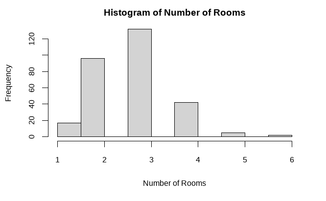

```r
# Histogram
hist(houses$Rooms, xlab = "Number of Rooms", main = "Histogram of Number of Rooms" )
```

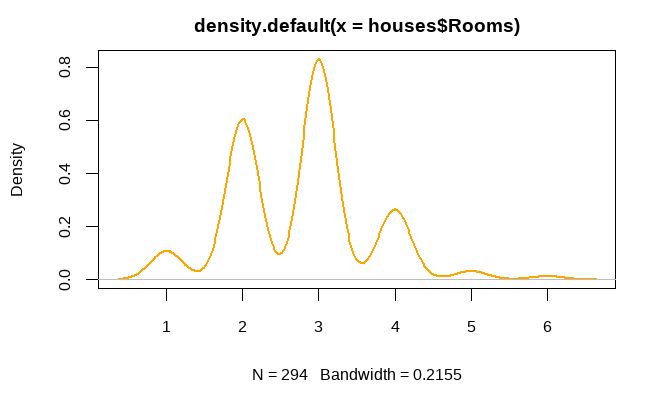

```r
# Density plot
rooms_den <- density(houses$Rooms)

plot(rooms_den, lwd= 2, col= "orange")
```

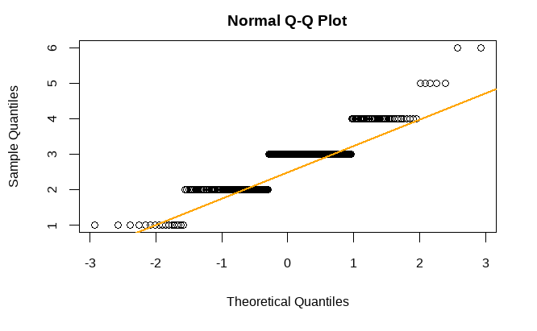

```r
# Q-Q plot
qqnorm(houses$Rooms)
qqline(houses$Rooms, col = "orange", lwd = 2)
```

```r
# Skewness
skewness(houses$Rooms)
```

```
[1] 0.3757163
```

```r
# Kurtosis
kurtosis(houses$Rooms)
```

```
[1] 3.686836
```

The distribution looks skewed, the value of skew indicates that we have a positive skewness. Positive value of kurtosis means that the distribution is leptokurtic (pointy).

*Bedrooms*:

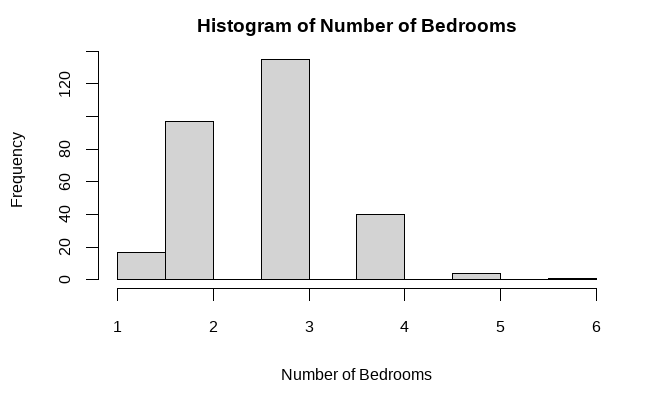

```r
# Histogram
hist(houses$Bedrooms, xlab = "Number of Bedrooms", main = "Histogram of Number of Bedrooms" )
```

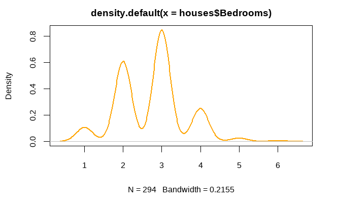

```r
# Density plot
bedrooms_den <- density(houses$Bedrooms)

plot(bedrooms_den, lwd= 2, col= "orange")
```

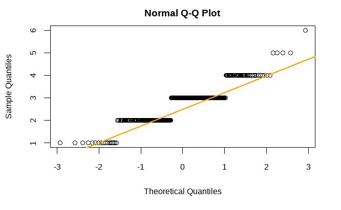

```r
# Q-Q plot
qqnorm(houses$Bedrooms)
qqline(houses$Bedrooms, col = "orange", lwd = 2)
```

```r
# Skewness
skewness(houses$Bedrooms)
```

```
[1] 0.2391407
```

```r
# Kurtosis
kurtosis(houses$Bedrooms)
```

```
[1] 3.427451
```

In this case, the distribution is not normal although the value of skew that indicates skewness to the right is small. Positive value of kurtosis means that the distribution is leptokurtic.

*Bathroom*:

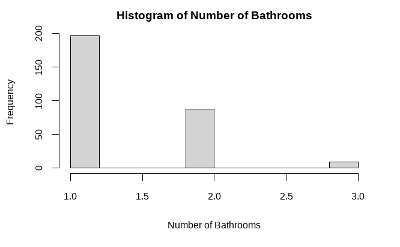

```r
# Histogram
hist(houses$Bathroom, xlab = "Number of Bathrooms", main = "Histogram of Number of Bathrooms" )
```

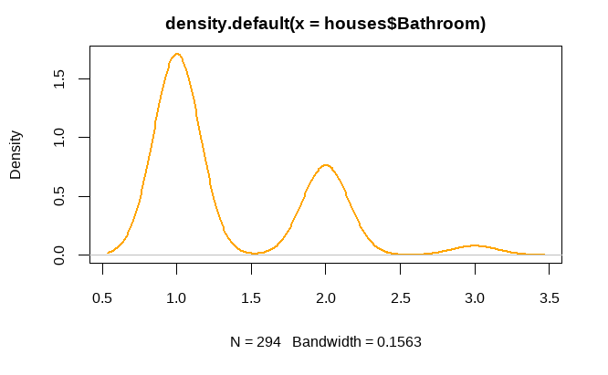

```r
# Density plot
bathrooms_den <- density(houses$Bathroom)

plot(bathrooms_den, lwd= 2, col= "orange")
```

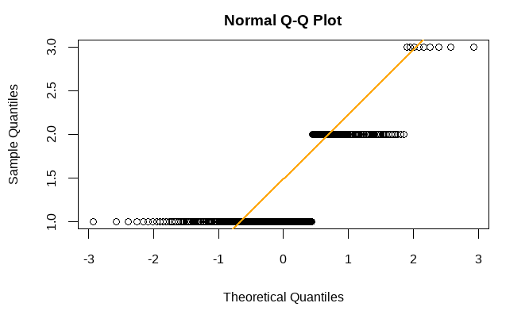

```r
# Q-Q plot
qqnorm(houses$Bathroom)
qqline(houses$Bathroom, col = "orange", lwd = 2)
```

```r
# Skewness
skewness(houses$Bathroom)
```

```
[1] 1.153214
```

```r
# Kurtosis
kurtosis(houses$Bathroom)
```

```
[1] 3.318589
```

The most common number of bathrooms in houses is 1, that is why the distribution is once again positively skewed, and has a positive kurtosis.

*Car*:

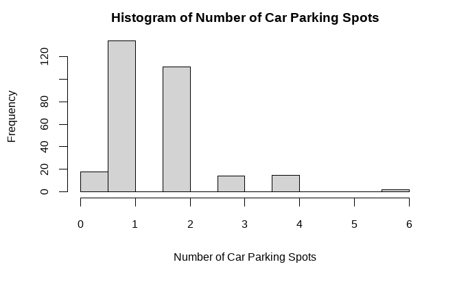

```r
# Histogram
hist(houses$Car, xlab = "Number of Car Parking Spots", main = "Histogram of Number of Car Parking Spots" )
```

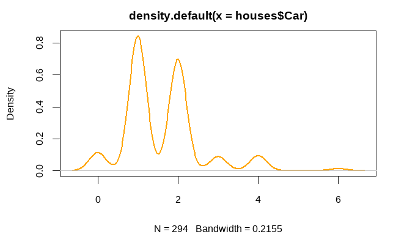

```r
# Density plot
car_den <- density(houses$Car)

plot(car_den, lwd= 2, col= "orange")
```

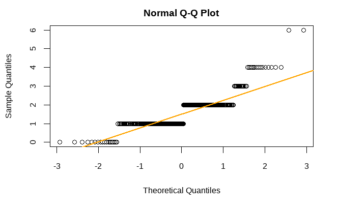

```r
# Q-Q plot
qqnorm(houses$Car)
qqline(houses$Car, col = "orange", lwd = 2)
```

```r
# Skewness
skewness(houses$Car)
```

```
[1] 1.281102
```

```r
# Kurtosis
kurtosis(houses$Car)
```

```
[1] 6.049199
```

Similarly to previous variables, we can notice positive skewness and kurtosis values when analysing *Car* variable plots, meaning the data is asymmetrical.

*Landsize*:

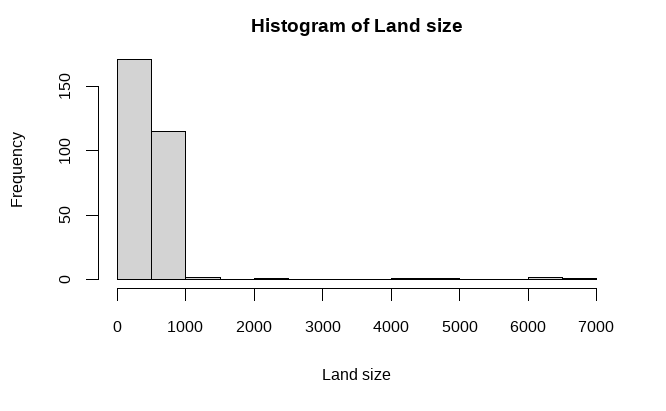

```r
# Histogram
hist(houses$Landsize, xlab = "Land size", main = "Histogram of Land size" )
```

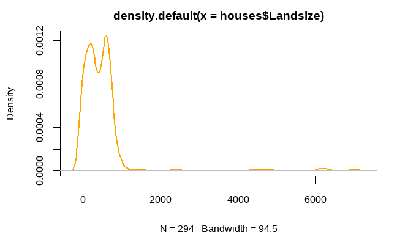

```r
# Density plot
landsize_den <- density(houses$Landsize)

plot(landsize_den, lwd= 2, col= "orange")
```

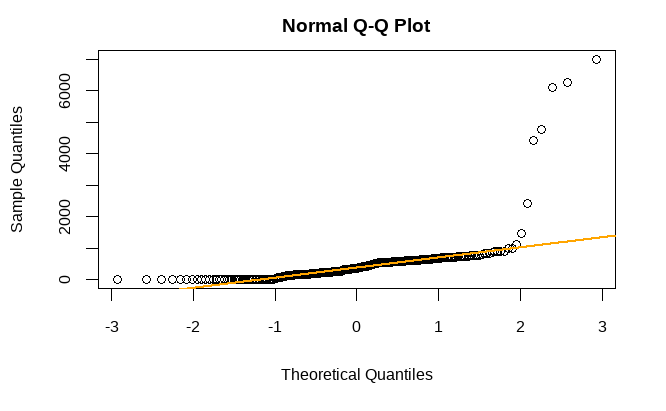

```r
# Q-Q plot
qqnorm(houses$Landsize)
qqline(houses$Landsize, col = "orange", lwd = 2)
```

```r
# Skewness
skewness(houses$Landsize)
```

```
[1] 6.148613
```

```r
# Kurtosis
kurtosis(houses$Landsize)
```

```
[1] 46.30993
```

What the visualisations plotted above show is that there are more properties with smaller land size. Also, it is worth mentioning that such distribution could be due to significant amount of values of zero in *Landsize*.

*BuildingArea*:

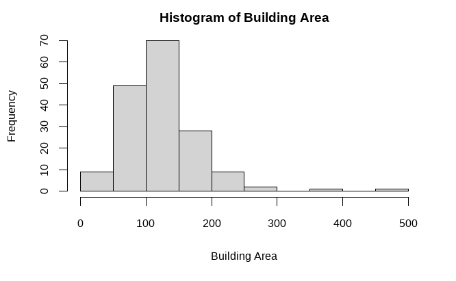

```r
# Histogram
hist(houses$BuildingArea, xlab = "Building Area", main = "Histogram of Building Area" )
```

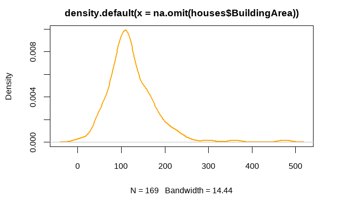

```r
# Density plot
buildArea_den <- density(na.omit(houses$BuildingArea)) # we need to omit missing values

plot(buildArea_den, lwd= 2, col= "orange")
```

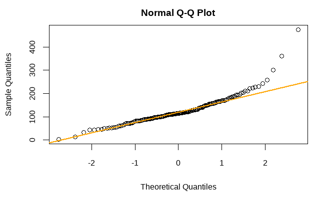

```r
# Q-Q plot
qqnorm(houses$BuildingArea)
qqline(houses$BuildingArea, col = "orange", lwd = 2)
```

```r
# Skewness
skewness(na.omit(houses$BuildingArea))
```

```
[1] 1.979843
```

```r
# Kurtosis
kurtosis(na.omit(houses$BuildingArea))
```

```
[1] 11.57436
```

In case of analysing *BuildingArea*, similar traits to previous variables have been spotted, like positive skewness and kurtosis. Moreover, due to missing values, na.omit() function was used in order to compute measures of non-normality. Although some outliers have been spotted on the Q-Q plot, it is difficult to tell whether such values are errors. I suppose more information would be necessary in order to make a judgement and take an action.

*YearBuilt*:

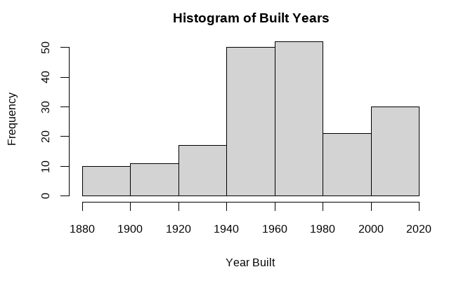

```r
# Histogram
hist(houses$YearBuilt, xlab = "Year Built", main = "Histogram of Built Years" )
```

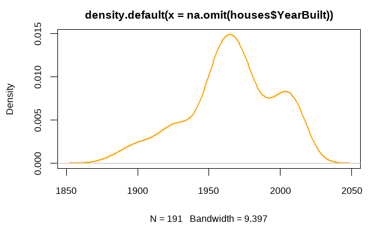

```r
# Density plot
yearBuilt_den <- density(na.omit(houses$YearBuilt))

plot(yearBuilt_den, lwd= 2, col= "orange")
```

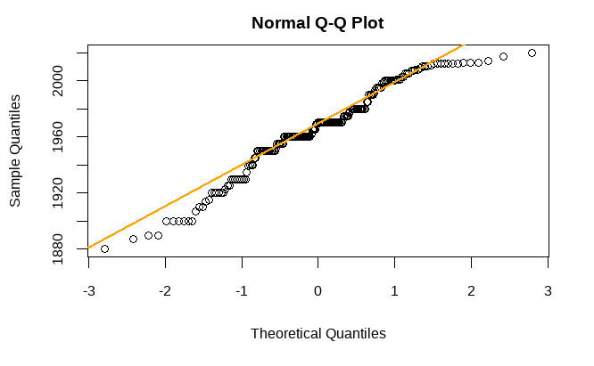

```r
# Q-Q plot
qqnorm(houses$YearBuilt)
qqline(houses$YearBuilt, col = "orange", lwd = 2)
```

```r
# Skewness
skewness(na.omit(houses$YearBuilt))
```

```
[1] -0.4443582
```

```r
# Kurtosis
kurtosis(na.omit(houses$YearBuilt))
```

```
[1] 2.796102
```

*Distance*:

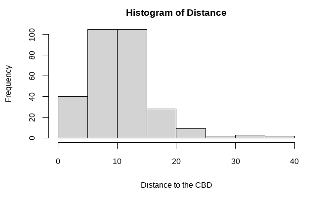

```r
# Histogram
hist(houses$Distance, xlab = "Distance to the CBD", main = "Histogram of Distance" )
```

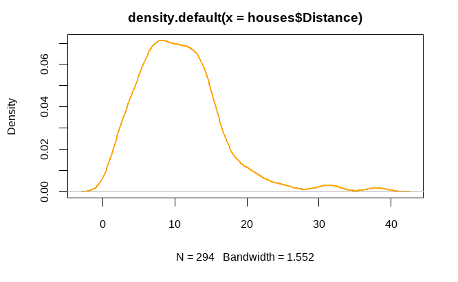

```r
# Density plot
distance_den <- density(houses$Distance)

plot(distance_den, lwd= 2, col= "orange")
```

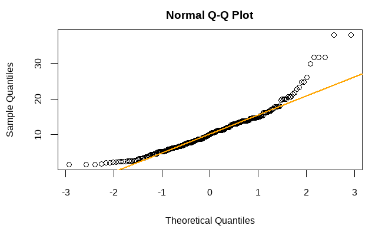

```r
# Q-Q plot
qqnorm(houses$Distance)
qqline(houses$Distance, col = "orange", lwd = 2)
```

```r
# Skewness
skewness(houses$Distance)
```

```
[1] 1.384619
```

```r
# Kurtosis
kurtosis(houses$Distance)
```

```
[1] 6.640362
```

From the plots it has been noticed that the majority of the properties are close to the Commercial Business District, so the *Distance* is not normally distributed. Although some outliers have been spotted on the Q-Q plot, they seem to follow the pattern of the sorted data, so they are considered to be interesting features of the variable, rather than errors in the data.

*PropertyCount*:

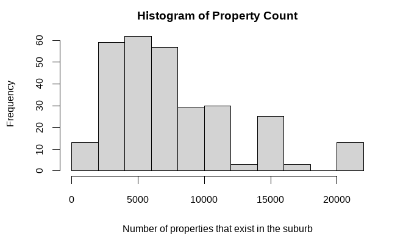

```r
# Histogram
hist(houses$PropertyCount, xlab = "Number of properties that exist in the suburb", main = "Histogram of Property Count" )
```

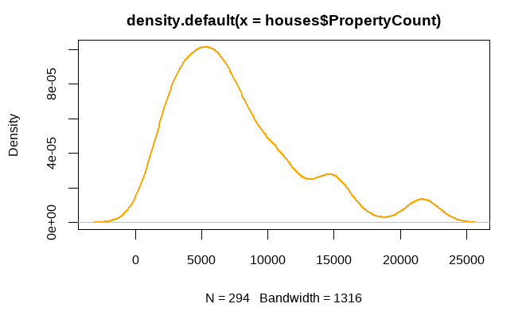

```r
# Density plot
pc_den <- density(houses$PropertyCount)

plot(pc_den, lwd= 2, col= "orange")
```

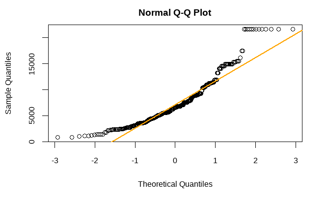

```r
# Q-Q plot
qqnorm(houses$PropertyCount)
qqline(houses$PropertyCount, col = "orange", lwd = 2)
```

```r
# Skewness
skewness(houses$PropertyCount)
```

```
[1] 1.168081
```

```r
# Kurtosis
kurtosis(houses$PropertyCount)
```

```
[1] 4.049701
```

The data in *PropertyCount* is not normally distributed, there is an apparent trend of properties having a comparingly small to medium number of properties that exist in the suburb. Same conclusion can be reached after analysing Q-Q plot and values of skewness and kurtosis.